# Machine Learning Project

Tim Qiu

02/08/2020

# Machine Learning Project

## SUMMARY

This machine learning project utilizes the [Human Activity Recognition](http://web.archive.org/web/20161224072740/http:/groupware.les.inf.puc-rio.br/har) datasets. In particular, the weightlifting subsets were used for this project. In short, many sensors placed on human participants collected data as they completed basic resistance training movements. A professional trainer rated the quality of the subjects movements. This project attempts via machine learning methods to predict the quality of movement during weightlifting by modelling the sensor data.

## PREPROCESS

### Load Packages

```r
library(tidyverse)
library(caret)
library(skimr)
library(Rmisc)
library(kableExtra)
library(rattle)
library(rpart.plot)
library(grid)
library(gridExtra)

##arrange df vars by position
##'vars' must be a named vector, e.g. c("var.name"=1)
arrange.vars <- function(data, vars){
    ##stop if not a data.frame (but should work for matrices as well)
    stopifnot(is.data.frame(data))

    ##sort out inputs
    data.nms <- names(data)
    var.nr <- length(data.nms)
    var.nms <- names(vars)
    var.pos <- vars
    ##sanity checks
    stopifnot( !any(duplicated(var.nms)),
               !any(duplicated(var.pos)) )
    stopifnot( is.character(var.nms),
               is.numeric(var.pos) )
    stopifnot( all(var.nms %in% data.nms) )
    stopifnot( all(var.pos > 0),
               all(var.pos <= var.nr) )

    ##prepare output
    out.vec <- character(var.nr)
    out.vec[var.pos] <- var.nms
    out.vec[-var.pos] <- data.nms[ !(data.nms %in% var.nms) ]
    stopifnot( length(out.vec)==var.nr )

    ##re-arrange vars by position
    data <- data[ , out.vec]
    return(data)
}
```

### Load Data

```r
setwd("C:/Users/Tim/Google Drive/exc/machineLearning/ml_CourseProject")
print(paste0("Working Directory: ", getwd()))
```

```
## [1] "Working Directory: C:/Users/Tim/Google Drive/exc/machineLearning/ml_CourseProject"
```

```r
dataTrain <- read.csv("ml_trainingData.csv")
dataTest <- read.csv("ml_testingData.csv")

# View(dataTrain)
# View(dataTest)
```

### Clean Data

##### Steps in cleaning

1. Remove variables with near zero variance
2. Remove variables that contain over 95% NA values
3. Remove irrelevant variables upon visual inspection

```r
idim <- dim(dataTrain) #get initial training data dimensions

dataTrain <- dataTrain[,-c(1:5)]  #first 5 columns are personal useless info
dataTest <- dataTest[,-c(1:5)]

rmcol <- nearZeroVar(dataTrain)  #Remove near zero variance predictors
dataTrain <- dataTrain[,-rmcol]
dataTest <- dataTest[,-rmcol]

rmna <- sapply(dataTrain, function(x){mean(is.na(x))}) > 0.95 #Remove columns with more than 95% NA obs
dataTrain <- dataTrain[, rmna == FALSE]                       #mean() CAN BE APPLIED TO BOOLEAN!
dataTest <- dataTest[, rmna == FALSE]

fdim <- dim(dataTrain) #get final training data dimensions

dataTrain$classe <- as.factor(dataTrain$classe)  #declare classe as factor

dimchg <- rbind(idim, fdim) #generate table displaying change in dimensions from cleaning
dimchg <- cbind(c("raw", "clean"), dimchg)
dimchg <- as.data.frame(dimchg)
kable(x = dimchg,
      format = 'html',
      col.names = c("change", "rows", "cols"),
      table.attr = "style = \"color: black;\"",
      caption = "Table 1. Dimension Changes",
      row.names = FALSE) %>%
  kable_styling(bootstrap_options = "basic",
                full_width = FALSE)
```

Table 1. Dimension Changes

| change | rows | cols |
| --- | --- | --- |
| raw | 19622 | 160 |
| clean | 19622 | 54 |

### Descriptives

Produces table with summary statistics of training data.

```r
trainskim <- skim(dataTrain) #using skimr grabs descriptive stats
trainskim <- trainskim[, c(1:2, 8:10, 12, 14:15)]  #collect only useful columns for display
kable(x = trainskim,
      format = 'html',
      digits = 2,
      col.names = c("type", "var", "M", "SD", "0%", "median", "100%", "hist"),
      caption = "Table 2. Descriptive Statistics of Training Set",
      table.attr = "style = \"color: black;\"") %>%
  kable_styling(bootstrap_options = "striped",
                fixed_thead = TRUE,
                full_width = FALSE)
```

Table 2. Descriptive Statistics of Training Set

| type | var | M | SD | 0% | median | 100% | hist |
| --- | --- | --- | --- | --- | --- | --- | --- |
| factor | classe | NA | NA | NA | NA | NA | NA |
| numeric | num_window | 430.64 | 247.91 | 1.00 | 424.00 | 864.00 | ▇▇▇▇▇ |
| numeric | roll_belt | 64.41 | 62.75 | -28.90 | 113.00 | 162.00 | ▇▁▁▅▅ |
| numeric | pitch_belt | 0.31 | 22.35 | -55.80 | 5.28 | 60.30 | ▃▁▇▅▁ |
| numeric | yaw_belt | -11.21 | 95.19 | -180.00 | -13.00 | 179.00 | ▁▇▅▁▃ |
| numeric | total_accel_belt | 11.31 | 7.74 | 0.00 | 17.00 | 29.00 | ▇▁▂▆▁ |
| numeric | gyros_belt_x | -0.01 | 0.21 | -1.04 | 0.03 | 2.22 | ▁▇▁▁▁ |
| numeric | gyros_belt_y | 0.04 | 0.08 | -0.64 | 0.02 | 0.64 | ▁▁▇▁▁ |
| numeric | gyros_belt_z | -0.13 | 0.24 | -1.46 | -0.10 | 1.62 | ▁▂▇▁▁ |
| numeric | accel_belt_x | -5.59 | 29.64 | -120.00 | -15.00 | 85.00 | ▁▁▇▁▂ |
| numeric | accel_belt_y | 30.15 | 28.58 | -69.00 | 35.00 | 164.00 | ▁▇▇▁▁ |
| numeric | accel_belt_z | -72.59 | 100.45 | -275.00 | -152.00 | 105.00 | ▁▇▁▅▃ |
| numeric | magnet_belt_x | 55.60 | 64.18 | -52.00 | 35.00 | 485.00 | ▇▁▂▁▁ |
| numeric | magnet_belt_y | 593.68 | 35.68 | 354.00 | 601.00 | 673.00 | ▁▁▁▇▃ |
| numeric | magnet_belt_z | -345.48 | 65.21 | -623.00 | -320.00 | 293.00 | ▁▇▁▁▁ |
| numeric | roll_arm | 17.83 | 72.74 | -180.00 | 0.00 | 180.00 | ▁▃▇▆▂ |
| numeric | pitch_arm | -4.61 | 30.68 | -88.80 | 0.00 | 88.50 | ▁▅▇▂▁ |
| numeric | yaw_arm | -0.62 | 71.36 | -180.00 | 0.00 | 180.00 | ▁▃▇▃▂ |
| numeric | total_accel_arm | 25.51 | 10.52 | 1.00 | 27.00 | 66.00 | ▃▆▇▁▁ |
| numeric | gyros_arm_x | 0.04 | 1.99 | -6.37 | 0.08 | 4.87 | ▁▃▇▆▂ |
| numeric | gyros_arm_y | -0.26 | 0.85 | -3.44 | -0.24 | 2.84 | ▁▂▇▂▁ |
| numeric | gyros_arm_z | 0.27 | 0.55 | -2.33 | 0.23 | 3.02 | ▁▂▇▂▁ |
| numeric | accel_arm_x | -60.24 | 182.04 | -404.00 | -44.00 | 437.00 | ▇▅▇▅▁ |
| numeric | accel_arm_y | 32.60 | 109.87 | -318.00 | 14.00 | 308.00 | ▁▃▇▆▂ |
| numeric | accel_arm_z | -71.25 | 134.65 | -636.00 | -47.00 | 292.00 | ▁▁▅▇▁ |
| numeric | magnet_arm_x | 191.72 | 443.64 | -584.00 | 289.00 | 782.00 | ▆▃▂▃▇ |
| numeric | magnet_arm_y | 156.61 | 201.91 | -392.00 | 202.00 | 583.00 | ▁▅▅▇▂ |
| numeric | magnet_arm_z | 306.49 | 326.62 | -597.00 | 444.00 | 694.00 | ▁▂▂▃▇ |
| numeric | roll_dumbbell | 23.84 | 69.93 | -153.71 | 48.17 | 153.55 | ▂▂▃▇▂ |
| numeric | pitch_dumbbell | -10.78 | 36.99 | -149.59 | -20.96 | 149.40 | ▁▆▇▂▁ |
| numeric | yaw_dumbbell | 1.67 | 82.52 | -150.87 | -3.32 | 154.95 | ▃▇▅▅▆ |
| numeric | total_accel_dumbbell | 13.72 | 10.23 | 0.00 | 10.00 | 58.00 | ▇▅▃▁▁ |
| numeric | gyros_dumbbell_x | 0.16 | 1.51 | -204.00 | 0.13 | 2.22 | ▁▁▁▁▇ |
| numeric | gyros_dumbbell_y | 0.05 | 0.61 | -2.10 | 0.03 | 52.00 | ▇▁▁▁▁ |
| numeric | gyros_dumbbell_z | -0.13 | 2.29 | -2.38 | -0.13 | 317.00 | ▇▁▁▁▁ |
| numeric | accel_dumbbell_x | -28.62 | 67.32 | -419.00 | -8.00 | 235.00 | ▁▁▆▇▁ |
| numeric | accel_dumbbell_y | 52.63 | 80.75 | -189.00 | 41.50 | 315.00 | ▁▇▇▅▁ |
| numeric | accel_dumbbell_z | -38.32 | 109.47 | -334.00 | -1.00 | 318.00 | ▁▆▇▃▁ |
| numeric | magnet_dumbbell_x | -328.48 | 339.72 | -643.00 | -479.00 | 592.00 | ▇▂▁▁▂ |
| numeric | magnet_dumbbell_y | 220.97 | 326.87 | -3600.00 | 311.00 | 633.00 | ▁▁▁▁▇ |
| numeric | magnet_dumbbell_z | 46.05 | 139.96 | -262.00 | 13.00 | 452.00 | ▁▇▆▂▂ |
| numeric | roll_forearm | 33.83 | 108.04 | -180.00 | 21.70 | 180.00 | ▃▂▇▂▇ |
| numeric | pitch_forearm | 10.71 | 28.15 | -72.50 | 9.24 | 89.80 | ▁▁▇▃▁ |
| numeric | yaw_forearm | 19.21 | 103.22 | -180.00 | 0.00 | 180.00 | ▅▅▇▆▇ |
| numeric | total_accel_forearm | 34.72 | 10.06 | 0.00 | 36.00 | 108.00 | ▁▇▂▁▁ |
| numeric | gyros_forearm_x | 0.16 | 0.65 | -22.00 | 0.05 | 3.97 | ▁▁▁▁▇ |
| numeric | gyros_forearm_y | 0.08 | 3.10 | -7.02 | 0.03 | 311.00 | ▇▁▁▁▁ |
| numeric | gyros_forearm_z | 0.15 | 1.75 | -8.09 | 0.08 | 231.00 | ▇▁▁▁▁ |
| numeric | accel_forearm_x | -61.65 | 180.59 | -498.00 | -57.00 | 477.00 | ▂▆▇▅▁ |
| numeric | accel_forearm_y | 163.66 | 200.13 | -632.00 | 201.00 | 923.00 | ▁▂▇▅▁ |
| numeric | accel_forearm_z | -55.29 | 138.40 | -446.00 | -39.00 | 291.00 | ▁▇▅▅▃ |
| numeric | magnet_forearm_x | -312.58 | 346.96 | -1280.00 | -378.00 | 672.00 | ▁▇▇▅▁ |
| numeric | magnet_forearm_y | 380.12 | 509.37 | -896.00 | 591.00 | 1480.00 | ▂▂▂▇▁ |
| numeric | magnet_forearm_z | 393.61 | 369.27 | -973.00 | 511.00 | 1090.00 | ▁▁▂▇▃ |

### Partition

Split Training Data into Train/Test sets for model building

```r
split <- createDataPartition(y = dataTrain$classe, p = 0.7, list = FALSE)
trainset <- dataTrain[split,]
testset <- dataTrain[-split,]
```

## TRAINING

### Approach

Here are the models we will use  
Basic:  
1. ‘rpart’ - Classification and Regression Trees

Enhancements:  
2. ‘gbm’ - Gradient Boosting Model (BOOST)  
3. ‘treebag’ - Bagged CARTS (BAG)  
4. ‘rf’ - Random Forest

Set seed for reproducability

```r
set.seed(42069)
```

### rpart

Train Basic classification and Regression Tree Model

```r
mod_rpart <- train(classe ~ .,     #Train CART model
                  data = trainset,
                  method = "rpart",
                  trControl = trainControl(method ="cv", number = 5))
```

### gbm

Train Gradient Bossted Trees Model

```r
mod_gbm <- train(classe ~.,
                 data = trainset,
                 method = "gbm",
                 verbose = FALSE)
```

### treebag

Train Bagged Trees Model

```r
mod_treebag <- train(classe ~.,
                 data = trainset,
                 method = "treebag")
```

### rf

Train Random Forest Model

```r
mod_rf <- train(classe ~.,
                data = trainset,
                method = "rf",
                tuneGrid = data.frame(mtry=2))
```

## PREDICTION

### rpart

```r
pred_rpart <- predict(mod_rpart, newdata = testset)  #predict using CART
cm_rpart <- confusionMatrix(data = pred_rpart, reference = testset$classe)  #Compute model statistics
stat_rpart <- cm_rpart$overall[1:5]  #store relevant statistics
```

### gbm

```r
pred_gbm <- predict(mod_gbm, newdata = testset) #predict using gradient boost trees
cm_gbm <- confusionMatrix(data = pred_gbm, reference = testset$classe) #compute model statistic
stat_gbm <- cm_gbm$overall[1:5]
```

### treebag

```r
pred_treebag <- predict(mod_treebag, newdata = testset) #predict using bagged trees
cm_treebag <- confusionMatrix(data = pred_treebag, reference = testset$classe) #compute model statistics
stat_treebag <- cm_treebag$overall[1:5]
```

### rf

```r
pred_rf <- predict(mod_rf, newdata = testset) #predict using random forest model
cm_rf <- confusionMatrix(data = pred_rf, reference = testset$classe)
stat_rf <- cm_rf$overall[1:5]
```

## ANALYSIS

### Confusion Matrix

Generate confusion matrices for each model in the ggplot2 environment. Displays as grid.

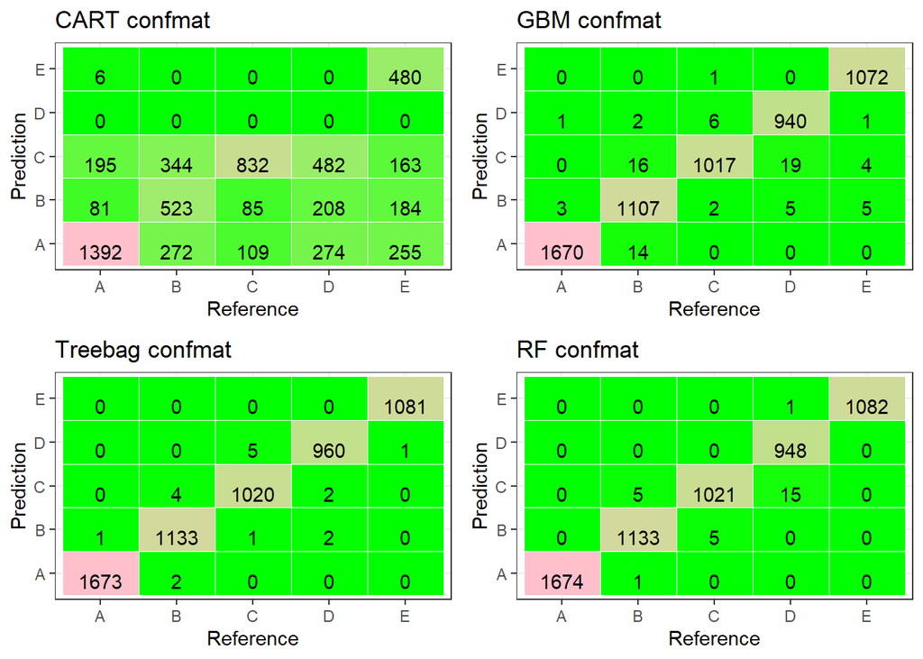

```r
#Generate confusion matrix tileplots for all four models
pcm_rpart <- ggplot(data = as.data.frame(cm_rpart$table), mapping = aes(x = Reference, y = Prediction)) +
  geom_tile(aes(fill = Freq), colour = "white") +
  geom_text(aes(label = sprintf("%1.0f", Freq)), vjust = 1) +
  scale_fill_gradient(low = "green", high = "pink") +
  theme_bw() +
  theme(legend.position = "none") +
  ggtitle("CART confmat")

pcm_gbm <- ggplot(data = as.data.frame(cm_gbm$table), mapping = aes(x = Reference, y = Prediction)) +
  geom_tile(aes(fill = Freq), colour = "white") +
  geom_text(aes(label = sprintf("%1.0f", Freq)), vjust = 1) +
  scale_fill_gradient(low = "green", high = "pink") +
  theme_bw() + theme(legend.position = "none") +
  ggtitle("GBM confmat")

pcm_treebag <- ggplot(data = as.data.frame(cm_treebag$table), mapping = aes(x = Reference, y = Prediction)) +
  geom_tile(aes(fill = Freq), colour = "white") +
  geom_text(aes(label = sprintf("%1.0f", Freq)), vjust = 1) +
  scale_fill_gradient(low = "green", high = "pink") +
  theme_bw() + theme(legend.position = "none") +
  ggtitle("Treebag confmat")

pcm_rf <- ggplot(data = as.data.frame(cm_rf$table), mapping = aes(x = Reference, y = Prediction)) +
  geom_tile(aes(fill = Freq), colour = "white") +
  geom_text(aes(label = sprintf("%1.0f", Freq)), vjust = 1) +
  scale_fill_gradient(low = "green", high = "pink") +
  theme_bw() + theme(legend.position = "none") +
  ggtitle("RF confmat")


grid.arrange(pcm_rpart, pcm_gbm, pcm_treebag, pcm_rf, #display model
             nrow = 2,
             ncol = 2)
```

It would seem all models except the first model (rpart) have very accurate confusion matrices. Thus Gradient Boost, Bagged Trees and Random Forest are all viable models for assessing prediction.

### Model Statistics

Gathers the stored model statistics from the predictions section and displays in a table for comparison.

```r
stat_mod <- rbind(stat_rpart, stat_gbm, stat_treebag, stat_rf) #gather model statistics
stat_mod <- as.data.frame(stat_mod)
stat_mod$model <- c("Basic CART", "Gradient Boosted", "Bagged Trees", "Random Forest")
# stat_mod

stat_mod <- arrange.vars(stat_mod, c("model" = 1,"Kappa" = 2 ,"AccuracyNull" = 3,"Accuracy" = 4, "AccuracyLower" = 5, "AccuracyUpper" = 6))

kable(x = stat_mod,  #generate table
      format = "html",
      digits = 3,
      row.names = FALSE,
      align = 'c',
      col.names = c("Model", "K", "Naive Acc.", "Model Acc.", "CI-lo", "CI-hi"),
      table.attr = "style = \"color: black;\"",
      caption = "Table 3. Comparison of Model Statistics") %>%
  kable_styling(bootstrap_options = c('striped'),
                full_width = FALSE)
```

Table 3. Comparison of Model Statistics

| Model | K | Naive Acc. | Model Acc. | CI-lo | CI-hi |
| --- | --- | --- | --- | --- | --- |
| Basic CART | 0.420 | 0.284 | 0.548 | 0.536 | 0.561 |
| Gradient Boosted | 0.983 | 0.284 | 0.987 | 0.983 | 0.989 |
| Bagged Trees | 0.996 | 0.284 | 0.997 | 0.995 | 0.998 |
| Random Forest | 0.994 | 0.284 | 0.995 | 0.993 | 0.997 |

## TEST

Final Prediction of Testing Dataset

```r
pred_fin <- predict(mod_rf, dataTest)
print(pred_fin)
```

```
##  [1] B A B A A E D B A A B C B A E E A B B B
## Levels: A B C D E
```